# Module 1 Summary: Introduction to Python and Its Business Applications

Author

Affiliation

Dr. Smith

University of South Florida

## Introduction

This document provides a concise summary of what we covered in Module 1, which laid the foundation for your Python journey in the business context.

## What We Learned

In Module 1, we covered:

1. **Why Python is valuable for business applications**
2. **How to set up the Thonny development environment**
3. **How to write and run your first Python program**
4. **Fundamental Python concepts: variables, data types, comments, print function**
5. **Basic debugging techniques**

Let’s review each of these key areas briefly.

## Mind Map: Module 1 Content

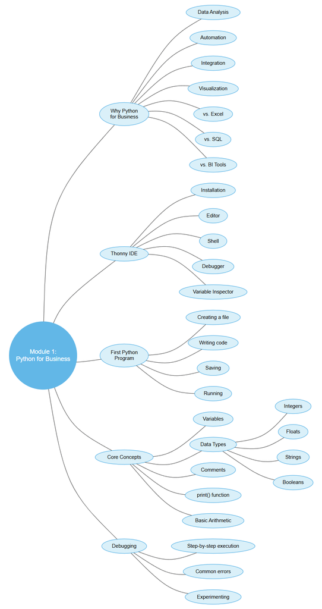

# 1. Why Python for Business?

Python has become an essential tool in the business world for several compelling reasons:

- **Readability and Simplicity**: Python’s clean syntax makes it accessible even to those without programming backgrounds
- **Versatility**: A single language that can handle diverse business needs
- **Powerful Libraries**: Ready-made tools for data analysis, visualization, and more
- **Community Support**: Vast resources and help available online

## Business Applications of Python

- **Data Analysis**: Clean, transform, and derive insights from business data
- **Automation**: Eliminate repetitive tasks like report generation and file manipulation
- **Visualization**: Create charts and graphs to communicate insights effectively
- **Integration**: Connect different business systems and data sources
- **Custom Solutions**: Build tailored applications for specific business needs

## Python vs. Traditional Business Tools

Python complements rather than replaces traditional business tools:

| Tool | Strengths | When Python Adds Value |
| --- | --- | --- |
| Excel | User-friendly, familiar interface | Handling large datasets, complex analysis, automation |
| SQL | Efficient data retrieval from databases | Performing analysis on retrieved data, cleaning messy data |
| BI Tools (Tableau, Power BI) | Interactive dashboards, visualization | Pre-processing data, advanced analytics, custom algorithms |

# 2. Setting Up Your Python Environment

We used **Thonny** as our Integrated Development Environment (IDE) because it’s:

- Designed specifically for beginners
- Has a clean, simple interface
- Includes Python built-in (no separate installation needed)
- Provides powerful debugging tools

## The Thonny Interface

Thonny’s key components include:

- **Editor**: Where you write your code (top panel)
- **Shell**: Where you see outputs and can test single commands (bottom panel)
- **Run Button (▶)**: Executes your entire program
- **Debug Button (🐞)**: Allows step-by-step execution
- **Variable Inspector**: Shows the current values of all variables

**Remember**

The editor is for writing multi-line programs, while the shell is for seeing results and quick testing. When in doubt, look to the shell for error messages and program output!

# 3. Writing Your First Python Program

We created a simple business program that:

1. Displayed a welcome message
2. Stored revenue data for different regions in variables
3. Calculated the total revenue
4. Displayed the result

```python
# My First Business Python Program
print("Welcome to Business Python!")

north_revenue = 50000
south_revenue = 40000
east_revenue = 45000
west_revenue = 55000

total_revenue = north_revenue + south_revenue + east_revenue + west_revenue

print("Total Revenue: $", total_revenue)
```

## Key Programming Concepts

### Variables

Variables store information that can be used later in your program:

```
 ┌─────────────────┐
 │ north_revenue   │
 ├─────────────────┤
 │     50000       │
 └─────────────────┘
```

### Data Types

Python works with different kinds of data:

- **Integers (int)**: Whole numbers like `42`, `1000`, `-5`
- **Floats**: Decimal numbers like `3.14`, `42.5`, `-0.01`
- **Strings (str)**: Text data in quotes like `"Hello"`, `'Python'`
- **Booleans (bool)**: True/False values like `True`, `False`

### Comments

Comments (beginning with `#`) explain your code but are ignored by Python:

```python
# This is a comment explaining what the next line does
revenue = 50000  # This is also a comment
```

### Print Function

The `print()` function displays information to the user:

```python
print("Hello, World!")  # Displays: Hello, World!
print("Total:", 100)    # Displays: Total: 100
```

### Basic Arithmetic

Python can perform calculations: - Addition: `total = a + b` - Subtraction: `difference = a - b` - Multiplication: `product = a * b` - Division: `quotient = a / b`

# 4. Debugging Your Code

Debugging is the process of finding and fixing errors in your code. Thonny’s debugger helps by:

- Executing your code one line at a time
- Showing you which line is about to be executed
- Displaying the current values of all variables
- Allowing you to inspect how values change

## Common Python Errors

| Error Type | Example | Solution |
| --- | --- | --- |
| SyntaxError | `print(Hello World)` | Add missing quotes: `print("Hello World")` |
| NameError | `print(total_revenu)` | Fix spelling: `print(total_revenue)` |
| TypeError | `print("Revenue: " + 50000)` | Use comma instead: `print("Revenue:", 50000)` |

**Python is Case-Sensitive!**

`revenue` and `Revenue` are different variables in Python. Always be consistent with capitalization.

# Course Roadmap

This module is just the beginning of your Python journey. Here’s what’s coming up:

**Your Python Learning Journey**

**Module 1: Introduction to Python and Its Business Applications** (Current Module) - Understanding Python’s role in business - Setting up your development environment with Thonny - Writing your first Python program - Basic debugging techniques

**Module 2: Variables and Expressions** - Creating and manipulating variables effectively - Understanding different data types in depth - Working with numeric and logical expressions - Best practices for variable naming in business contexts

**Module 3: Strings, Formatting, and I/O** - Working with text data - String manipulation and formatting techniques - Reading user input and displaying formatted output - Handling business text data (names, addresses, product descriptions)

**Module 4: Lists and Tuples** - Creating and working with ordered collections of data - List operations and methods - When to use tuples vs. lists - Representing business data like product catalogs and transaction histories

**Module 5: Dictionaries and Aggregation** - Using key-value pairs to organize data - Efficient data lookup and modification - Aggregating and filtering data - Representing complex business entities (customers, products, transactions)

**Module 6: Conditional Logic and Branching** - Making decisions in your code with if/else statements - Implementing business rules and logic - Complex conditions and logical operators - Creating business workflows with conditional execution

**Module 7: Looping** - Automating repetitive tasks - Iterating through collections of data - Different types of loops for different scenarios - Processing large datasets efficiently

**Module 8: Functions** - Creating reusable blocks of code - Organizing code for maintainability - Function parameters and return values - Building a library of business utility functions

**Module 9: Pandas and Data Analysis** - Introduction to the powerful Pandas library - Loading and analyzing structured data - Data cleaning and transformation - Performing business analysis on real datasets

**Module 11: Data Visualization** - Turning data into visual insights - Creating charts, graphs, and plots - Choosing the right visualization for your data - Building effective business dashboards

**Module 12: Capstone - Business Analysis Using Python** - Bringing all concepts together in a comprehensive project - Solving real business problems with Python - End-to-end business analysis workflow - Presenting data-driven insights

# Key Takeaways

1. **Python is a Powerful Business Tool**: Its simplicity, flexibility, and extensive libraries make it ideal for a wide range of business applications.
2. **Thonny Provides an Ideal Learning Environment**: The beginner-friendly IDE includes everything you need to write, run, and debug Python code.
3. **Variables Store Information**: They act as labeled containers for different types of data (numbers, text, etc.).
4. **Functions Perform Specific Tasks**: The `print()` function displays information to the user.
5. **Comments Explain Your Code**: They help others (and your future self) understand what your code does.
6. **Debugging is Essential**: Learning to find and fix errors is a critical skill for any programmer.

# Practice Exercises

Reinforce your learning with these exercises:

1. **Create a Basic Business Card Program**:
   - Store your name, title, company, and contact information in variables
   - Print them in a formatted way that resembles a business card
2. **Profit Calculator**:
   - Create variables for revenue and costs
   - Calculate the profit (revenue - costs)
   - Calculate the profit margin (profit / revenue)
   - Print both the profit and profit margin
3. **Debugging Practice**: Fix these broken lines of code:

   ```python
   Company name = "TechSolutions Inc."
   employee_count = "17"
   avg_salary = 65000
   print(Company_name, "has", employee_count, "employees")
   print("The total salary expense is $" + employee_count * avg_salary)
   ```

# Glossary

- **Algorithm**: A step-by-step procedure for solving a problem
- **Assignment**: The operation of storing a value in a variable (using `=`)
- **Boolean**: A data type with only two possible values: True or False
- **Bug**: An error in a program
- **Comment**: Text in code (preceded by `#`) that is ignored by Python
- **Data Type**: The classification of data (e.g., integers, strings)
- **Debugging**: The process of finding and fixing errors in code
- **Editor**: The area in Thonny where you write your code
- **Float**: A number with a decimal point
- **IDE**: Integrated Development Environment; software for writing code
- **Integer**: A whole number without a decimal point
- **Library**: A collection of pre-written code that can be reused
- **Print Function**: A command that displays information in the shell
- **Script**: A file containing Python code (saved with a .py extension)
- **Shell**: The area in Thonny where output appears
- **String**: A sequence of characters (text), always in quotes
- **Syntax**: The rules that define the structure of a programming language
- **Variable**: A named storage location in memory

# Next Steps

To prepare for the next module:

1. **Practice with Variables**: Create variables of different types and try operations on them
2. **Experiment with Print**: Try different ways of using the print function
3. **Try Debugging**: Introduce deliberate errors and use Thonny’s debugger to find them
4. **Think Business**: Consider how you might use variables to represent business data

Remember, programming is a skill that improves with practice! Even 15 minutes of coding each day will build your confidence and abilities.